# homework.funcAn.final

# 1 Overview

In this script, we will perform functional analysis of the identified, differential genes.

In the first part, we will do over-representation analysis (ORA).

In the second part, we will do functional class scoring using gene set enrichement analysis (GSEA).

```r
inpDir <- paste(getwd(), "../009_DESeq2clean/all_vs_GM", sep = "/")

Rat2Mouse_CHIP <- read_delim("../000_referenceseq/CHIP/Rat_Ensembl_Gene_ID_Mouse_Orthologs_MSigDB.v2023.2.Mm.chip",
    delim = "\t", escape_double = FALSE,
    trim_ws = TRUE)
#View(Rat2Mouse_CHIP)
```

# 2 Over-representation analysis (ORA)

## 2.1 import results of differential expression analysis

```r
l_df.res.all <- readRDS(paste(inpDir, "l_df.res.all.rds", sep = "/"))
names(l_df.res.all)
```

```
##  [1] "DM.vs.GM"                  "HC.vs.GM"
##  [3] "OA.vs.GM"                  "DM.vs.GM.noNa"
##  [5] "HC.vs.GM.noNa"             "OA.vs.GM.noNa"
##  [7] "DM.vs.GM.noNa.sigPadjUp"   "HC.vs.GM.noNa.sigPadjUp"
##  [9] "OA.vs.GM.noNa.sigPadjUp"   "DM.vs.GM.noNa.sigPadjDo"
## [11] "HC.vs.GM.noNa.sigPadjDo"   "OA.vs.GM.noNa.sigPadjDo"
## [13] "DM.vs.GM.noNa.sigPadjFcUp" "HC.vs.GM.noNa.sigPadjFcUp"
## [15] "OA.vs.GM.noNa.sigPadjFcUp" "DM.vs.GM.noNa.sigPadjFcDo"
## [17] "HC.vs.GM.noNa.sigPadjFcDo" "OA.vs.GM.noNa.sigPadjFcDo"
```

only DM vs GM is needed (we will subset from full result tables)

```r
df_DM.vs.GM.noNa <- l_df.res.all$DM.vs.GM.noNa

dim(df_DM.vs.GM.noNa)
```

```
## [1] 14200    10
```

```r
head(df_DM.vs.GM.noNa)
```

|  | symbol | baseMean | log2FoldChange | lfcSE | pvalue | padj | stat | lfcSE_not_shrunk | log2FoldChange_not_shrunk | ENSEMBLEID |
| --- | --- | --- | --- | --- | --- | --- | --- | --- | --- | --- |
| ENSRNOG00000017962 | Serpinb6a | 2698.2834 | 1.521481 | 0.1269637 | 3.398726e-34 | 4.826191e-30 | 12.19272 | 0.1263468 | 1.540511 | ENSRNOG00000017962 |
| ENSRNOG00000036859 | Gdpd5 | 2626.4817 | -1.424452 | 0.1308387 | 1.115440e-28 | 7.919621e-25 | -11.11049 | 0.1301176 | -1.445671 | ENSRNOG00000036859 |
| ENSRNOG00000010645 | Lgals3 | 1011.2636 | 4.198394 | 0.3897164 | 2.539839e-28 | 1.202191e-24 | 11.03678 | 0.3866145 | 4.266978 | ENSRNOG00000010645 |
| ENSRNOG00000017156 | Ankle1 | 263.7416 | -2.886005 | 0.2724518 | 1.370714e-27 | 4.866035e-24 | -10.88422 | 0.2700202 | -2.938958 | ENSRNOG00000017156 |
| ENSRNOG00000006019 | G0s2 | 7215.6078 | -1.754785 | 0.1654417 | 1.917902e-27 | 5.446840e-24 | -10.85357 | 0.1643201 | -1.783459 | ENSRNOG00000006019 |
| ENSRNOG00000052549 | Chga | 74009.7761 | -2.139749 | 0.2073436 | 3.488323e-26 | 8.255697e-23 | -10.58525 | 0.2057425 | -2.177837 | ENSRNOG00000052549 |

this is the number of sig. reg. genes that have a log2fc of over 1 (padj < 0.05 & abs(log2fc) > 1)

```r
nrow(df_DM.vs.GM.noNa[df_DM.vs.GM.noNa$padj < 0.05 &
                                 abs(df_DM.vs.GM.noNa$log2FoldChange) > 1, ])
```

```
## [1] 1127
```

### 2.2.1 download and import Reactome genesets

Reactome geneset can be downloaded from here [linkToMsigDb](https://www.gsea-msigdb.org/gsea/msigdb/download_file.jsp?filePath=/msigdb/release/2023.1.Mm/m2.cp.reactome.v2023.1.Mm.symbols.gmt%5D)

You need to register and login to MsigDb

Download m2.cp.reactome.v2023.1.Mm.symbols.gmt in current working directory.

Now read in and check object

```r
library(GSEABase)
gmt_r <- GSEABase::getGmt(paste("/proj/courses/transcriptomics/SS23/hw/011_clusterProfiler/inputData/m2.cp.reactome.v2023.1.Mm.symbols.gmt",
                                sep = "/"))
gmt_r # GeneSetCollection object
```

```
## GeneSetCollection
##   names: REACTOME_INTERLEUKIN_6_SIGNALING, REACTOME_APOPTOSIS, ..., REACTOME_ION_CHANNEL_TRANSPORT (1251 total)
##   unique identifiers: Stat3, Il6st, ..., Trak1 (9045 total)
##   types in collection:
##     geneIdType: NullIdentifier (1 total)
##     collectionType: NullCollection (1 total)
```

### 2.2.2 convert to dataframe and merge with results from differential expression analysis

The next step is to know in which genset each of the genes tested for differential regulation belongs to. Therefore, we generate a table, with two columns, one geneset, and one gene-symbol column.

First convert GeneSetCollection Object into a list.

```r
l_gs <- geneIds(gmt_r)
```

Then convert it into a data.frame using functions from the tidyverse universe [tidyverse](https://www.tidyverse.org/)

```r
df_gsToGene <- as.data.frame(unnest(enframe(l_gs,
                                            name = "geneset",
                                            value = "symbol"),
                                    cols = "symbol"))
dim(df_gsToGene)
```

```
## [1] 70591     2
```

```r
sum(duplicated(df_gsToGene$symbol))
```

```
## [1] 61546
```

```r
length(unique(df_gsToGene$symbol))
```

```
## [1] 9045
```

```r
head(df_gsToGene, n=4)
```

|  | geneset | symbol |
| --- | --- | --- |
| 1 | REACTOME_INTERLEUKIN_6_SIGNALING | Stat3 |
| 2 | REACTOME_INTERLEUKIN_6_SIGNALING | Il6st |
| 3 | REACTOME_INTERLEUKIN_6_SIGNALING | Jak2 |
| 4 | REACTOME_INTERLEUKIN_6_SIGNALING | Il6 |

## 2.3 extract unique genes from Reactome, und use to subset result from diff.exp.analysis

The genes in the Reactome database are our “universe”, within we try to find an association between the gensets and our differentially expressed genes. Subset results of differentially expressed genes to genes present in Reactome database.

```r
v_gInR <- unique(df_gsToGene$symbol)
```

Before subsetting, we check if we have duplicated gene symbols in our result tables

## 2.4 next code cell orthologue maps rat genes to the mouse orthologues

```r
df_DM.vs.GM.noNa$symbolmouse <- Rat2Mouse_CHIP$"Gene Symbol"[match(df_DM.vs.GM.noNa$ENSEMBLEID, Rat2Mouse_CHIP$"Probe Set ID")]
```

```r
sum(duplicated(df_DM.vs.GM.noNa$symbolmouse))
```

```
## [1] 1811
```

Show rows with duplicated gene symbols

```r
df_DM.vs.GM.noNa[duplicated(df_DM.vs.GM.noNa$symbolmouse) |
                 duplicated(df_DM.vs.GM.noNa$symbolmouse, fromLast=T), ]
```

|  | symbol | baseMean | log2FoldChange | lfcSE | pvalue | padj | stat | lfcSE_not_shrunk | log2FoldChange_not_shrunk | ENSEMBLEID | symbolmouse |
| --- | --- | --- | --- | --- | --- | --- | --- | --- | --- | --- | --- |
| ENSRNOG00000004487 | Nek2l1 | 334.038036 | -2.5038011165 | 0.26318171 | 1.100173e-22 | 1.735829e-19 | -9.802330689 | 0.26075797 | -2.556035836 | ENSRNOG00000004487 | Nek2 |
| ENSRNOG00000070523 | Mxd3 | 182.057649 | -2.7217207055 | 0.37354824 | 1.584651e-14 | 4.687927e-12 | -7.680503000 | 0.36701265 | -2.818841784 | ENSRNOG00000070523 | Mxd3 |
| ENSRNOG00000069437 | NA | 281.656361 | -1.5706658578 | 0.22024388 | 6.545675e-14 | 1.630677e-11 | -7.496675524 | 0.21700745 | -1.626834466 | ENSRNOG00000069437 | NA |
| ENSRNOG00000071217 | Chek1 | 636.222588 | -1.5384648175 | 0.21724210 | 9.942217e-14 | 2.277088e-11 | -7.441667556 | 0.21414636 | -1.593606011 | ENSRNOG00000071217 | Chek1 |
| ENSRNOG00000067060 | MGC105649 | 220.150744 | 1.2116372946 | 0.17058716 | 1.255692e-13 | 2.786067e-11 | 7.410768940 | 0.16879428 | 1.250895390 | ENSRNOG00000067060 | AA467197 |
| ENSRNOG00000063103 | Arpp19 | 7986.661924 | -0.7886818625 | 0.12159769 | 1.657595e-11 | 1.796782e-09 | -6.733386050 | 0.12086809 | -0.813851536 | ENSRNOG00000063103 | Arpp19 |
| ENSRNOG00000032487 | Sts | 334.964380 | 1.3579065745 | 0.22120956 | 6.960128e-11 | 6.255305e-09 | 6.521513876 | 0.21745462 | 1.418133298 | ENSRNOG00000032487 | NA |
| ENSRNOG00000013167 | Hmgb2l1 | 402.166068 | -2.4219161892 | 0.40881219 | 1.548680e-10 | 1.228562e-08 | -6.400500902 | 0.39870258 | -2.551896250 | ENSRNOG00000013167 | Hmgb2 |
| ENSRNOG00000067723 | Pclaf | 980.944003 | -2.3751624158 | 0.40260485 | 1.884487e-10 | 1.446471e-08 | -6.370470887 | 0.39268676 | -2.501599575 | ENSRNOG00000067723 | Pclaf |
| ENSRNOG00000067254 | NA | 387.143035 | -2.0521848459 | 0.34663532 | 1.962281e-10 | 1.489840e-08 | -6.364264202 | 0.33861637 | -2.155044030 | ENSRNOG00000067254 | NA |

[output cut: 1970 more lines]

We see that there are some genes with multiple Ensemble Gene Ids.

We simply remove one of the duplicates randomly, to avoid problems later, with subsetting, merging, …

```r
df_DM.vs.GM.noNa <- df_DM.vs.GM.noNa[!duplicated(df_DM.vs.GM.noNa$symbolmouse), ]
# consistency check, should be 0 afterwards
sum(duplicated(df_DM.vs.GM.noNa$symbolmouse))
```

```
## [1] 0
```

Next, we subset the data.

```r
# already use mouse symbols instead of rat symbols
df_DM.vs.GM.noNa <- df_DM.vs.GM.noNa[df_DM.vs.GM.noNa$symbolmouse %in% v_gInR, ]

dim(df_DM.vs.GM.noNa)
```

```
## [1] 6259   11
```

```r
length(v_gInR)
```

```
## [1] 9045
```

### 2.4.1 Add column indicating which genes are in Genset “Hemostasis” in Diff.Exp.Table

These symbols belong to HEMOSTASIS pathway

```r
#exploration in Hemostasis pathway, not relevant for PC12 cells
v_gHemo <- unique(df_gsToGene[grep("HEMOSTASIS", df_gsToGene$geneset), ]$symbol)
length(v_gHemo)
```

```
## [1] 628
```

```r
v_gccc <- unique(df_gsToGene[grep("CELL_CELL_COMMUNICATION", df_gsToGene$geneset), ]$symbol)
v_gecm <- unique(df_gsToGene[grep("EXTRACELLULAR_MATRIX_ORGANIZATION", df_gsToGene$geneset), ]$symbol)
v_gcc <- unique(df_gsToGene[grep("CELL_CYCLE_CHECKPOINTS", df_gsToGene$geneset), ]$symbol)
```

in diff. exp. table, indicate which genes belong to HEMOSTAIS (==1), and which not (==0)

```r
df_DM.vs.GM.noNa$isHemostasis <- ifelse(df_DM.vs.GM.noNa$symbolmouse %in% v_gHemo, 1, 0)
df_DM.vs.GM.noNa$isCellcellcomm <- ifelse(df_DM.vs.GM.noNa$symbolmouse %in% v_gccc, 1, 0)
df_DM.vs.GM.noNa$isECM <- ifelse(df_DM.vs.GM.noNa$symbolmouse %in% v_gecm, 1, 0)
df_DM.vs.GM.noNa$isCellcyclecheckpoints <- ifelse(df_DM.vs.GM.noNa$symbolmouse %in% v_gcc, 1, 0)
```

```r
table(df_DM.vs.GM.noNa$isHemostasis, useNA = "always")
```

```
##
##    0    1 <NA>
## 5908  351    0
```

```r
table(df_DM.vs.GM.noNa$isCellcellcomm, useNA = "always")
```

```
##
##    0    1 <NA>
## 6198   61    0
```

```r
table(df_DM.vs.GM.noNa$isECM, useNA = "always")
```

```
##
##    0    1 <NA>
## 6130  129    0
```

### 2.4.2 Add column indicating which genes sig. diff. regulated (padj & log2FC cutoff)

```r
df_DM.vs.GM.noNa$isSig <- ifelse(df_DM.vs.GM.noNa$padj < 0.05 &
                                 abs(df_DM.vs.GM.noNa$log2FoldChange) > 1, 1, 0)
table(df_DM.vs.GM.noNa$isSig, useNA = "always")
```

```
##
##    0    1 <NA>
## 5667  592    0
```

Note that because of subsetting, we only test a fraction of originally identified, sig. genes, for enrichtment in the pathways.

### 2.4.3 Check how the overlap between sig. genes and reactome hemostasis genset is

Do it just for DM vs GM

```r
tab <- table(df_DM.vs.GM.noNa$isSig,
             df_DM.vs.GM.noNa$isHemostasis)
tab_sum <- addmargins(tab, FUN = sum)
```

```
## Margins computed over dimensions
## in the following order:
## 1:
## 2:
```

```r
tab_sum
```

```
##
##          0    1  sum
##   0   5363  304 5667
##   1    545   47  592
##   sum 5908  351 6259
```

In the first row we have the not sig. genes, in the second row the sig. genes, and in the third row we have the sum. In the first column we have the genes that are not in the genset, in the second column we have the genes that are in the genset, and in the third column we have the sum.

### 2.4.4 Now use Fisher Exact test to test for sig. enrichment of Homeostasis genes in sig. reg. genes

```r
fisher.test(tab)
```

```
##
##  Fisher's Exact Test for Count Data
##
## data:  tab
## p-value = 0.01421
## alternative hypothesis: true odds ratio is not equal to 1
## 95 percent confidence interval:
##  1.080488 2.103148
## sample estimates:
## odds ratio
##   1.521248
```

We have a sig. enrichment of homeostasis genes in sig. genes. This is shown by the p-value, but you also have to interpret the odds ratio correctly, to judge if there is an enrichment, or a depletion, of homeostasis genes in the sig. genes.

### 2.4.5 Manually calculate Odds Ratio

The odds is the ratio of nr. event occurs / nr. event does not occur.

**Odds of homeostasis genes in sig. genes:** nr. homeostasis genes in sig. genes / nr. not homoestasis genes in sig. genes.

**Odds of homeostasis genes in not sig. genes:** nr. homeostasis genes in not sig. genes / nr. not homoestasis genes in not sig. genes.

```r
odds_sigG <- 47/545
odds_notSigG <- 304/5363
odds_sigG
```

```
## [1] 0.08623853
```

```r
odds_notSigG
```

```
## [1] 0.05668469
```

higher proportion of homeostasis genes in sig. genes than in not sig. genes.

Now calculate Odds ratio

if odds ratio over 1 than enrichement of geneset, if odds ratio under 1 than depletion of geneset

```r
odds_ratio <- odds_sigG/odds_notSigG
odds_ratio
```

```
## [1] 1.521373
```

## 2.5 Run over-representation analysis over different Genset collections using Bioconductor Tool Cluster Profiler

### 2.5.1 clusterProfiler needs Entrezid, or Ensemblid -> convert symbols to Entrezid

Use # already subsetted to correct universe, to see if we can reproduce our finding.

```r
ids <- bitr(df_DM.vs.GM.noNa$symbolmouse,
            fromType = "SYMBOL",
            toType = c("ENTREZID"),
            OrgDb = "org.Mm.eg.db")
dim(df_DM.vs.GM.noNa)
```

```
## [1] 6259   16
```

```r
dim(ids)
```

```
## [1] 6211    2
```

```r
head(ids)
```

|  | SYMBOL | ENTREZID |
| --- | --- | --- |
| 1 | Serpinb6a | 20719 |
| 2 | Chga | 12652 |
| 3 | Bak1 | 12018 |
| 4 | Nek2 | 18005 |
| 5 | Cbx2 | 12416 |
| 6 | Chrm4 | 12672 |

Some symbols did not match an Entrezid, and were dropped.

Check if NA or duplicated Values.

```r
for(i in seq_along(ids)){
  print(sum(duplicated(ids[, i])))
  print(sum(is.na(ids[, i])))
}
```

```
## [1] 0
## [1] 0
## [1] 0
## [1] 0
```

No.

### 2.5.2 Merge diff.Exp.Table with ids

```r
df_DM.vs.GM.noNa.m <- merge(x=df_DM.vs.GM.noNa,
                          y=ids,
                          by.x="symbolmouse",
                          by.y="SYMBOL",
                          all=F) # only keep symbols present in both tables
dim(df_DM.vs.GM.noNa.m)
```

```
## [1] 6211   17
```

```r
sum(is.na(df_DM.vs.GM.noNa.m$ENTREZID))
```

```
## [1] 0
```

```r
sum(duplicated(df_DM.vs.GM.noNa.m$ENTREZID))
```

```
## [1] 0
```

```r
head(df_DM.vs.GM.noNa.m)
```

|  | symbolmouse | symbol | baseMean | log2FoldChange | lfcSE | pvalue | padj | stat | lfcSE_not_shrunk | log2FoldChange_not_shrunk | ENSEMBLEID | isHemostasis | isCellcellcomm | isECM | isCellcyclecheckpoints | isSig | ENTREZID |
| --- | --- | --- | --- | --- | --- | --- | --- | --- | --- | --- | --- | --- | --- | --- | --- | --- | --- |
| 1 | 1600012H06Rik | 1600012H06Rik | 287.1349 | -0.05635848 | 0.2080102 | 0.7407534106 | 0.871356774 | -0.3308558 | 0.2506721 | -0.08293631 | ENSRNOG00000070184 | 0 | 0 | 0 | 0 | 0 | 67912 |
| 2 | 2310033P09Rik | RGD1304587 | 800.4431 | -0.14015493 | 0.1627921 | 0.3324167265 | 0.558353148 | -0.9692575 | 0.1772334 | -0.17178480 | ENSRNOG00000002944 | 0 | 0 | 0 | 0 | 0 | 67862 |
| 3 | 2610008E11Rik | 2610008E11Rik | 318.8267 | 0.57749586 | 0.1674807 | 0.0001556917 | 0.001565738 | 3.7818108 | 0.1667982 | 0.63079910 | ENSRNOG00000022871 | 0 | 0 | 0 | 0 | 0 | 72128 |
| 4 | 2810021J22Rik | 2810021J22Rik | 180.8747 | -0.06729365 | 0.2349608 | 0.6984907507 | 0.847904413 | -0.3873586 | 0.3006046 | -0.11644178 | ENSRNOG00000023431 | 0 | 0 | 0 | 0 | 0 | 69944 |
| 5 | A430033K04Rik | RGD1566386 | 675.2673 | 0.28536475 | 0.2415855 | 0.1347272051 | 0.311178646 | 1.4957178 | 0.2663841 | 0.39843545 | ENSRNOG00000028651 | 0 | 0 | 0 | 0 | 0 | 243308 |
| 6 | Aaas | Aaas | 859.0925 | -0.34977805 | 0.2128946 | 0.0493787747 | 0.151835990 | -1.9653065 | 0.2227366 | -0.43774576 | ENSRNOG00000013445 | 0 | 0 | 0 | 0 | 0 | 223921 |

Looks Good, we lost some genes, but have unique Entrezid, without NA values.

### 2.5.3 Make vector of EntrezId from sig. genes, and from all genes (== universe)

```r
# extract sig. res
df_DM.vs.GM.noNa.sig <- df_DM.vs.GM.noNa.m[df_DM.vs.GM.noNa.m$padj < 0.05 &
                                         abs(df_DM.vs.GM.noNa.m$log2FoldChange) > 1,  ]

v_DM.vs.GM.sig <- as.character(df_DM.vs.GM.noNa.sig$ENTREZID)
length(v_DM.vs.GM.sig)
```

```
## [1] 591
```

```r
# Create background dataset for hypergeometric testing using all genes tested for significance in the results
v_DM.vs.GM.all <- as.character(df_DM.vs.GM.noNa.m$ENTREZID)
length(v_DM.vs.GM.all)
```

```
## [1] 6211
```

### 2.5.4 run ClusterProfiler for ORA of Reactome genesets

```r
r_res <- enrichPathway(gene=v_DM.vs.GM.sig,
                   pvalueCutoff = 0.05,
                   readable=TRUE, # convert EntrezId to Gene symbols in result table
                   organism = "mouse",
                   universe = v_DM.vs.GM.all)
class(r_res) # enrichResult
```

```
## [1] "enrichResult"
## attr(,"package")
## [1] "DOSE"
```

### 2.5.5 extract all pathways

```r
df_res <- r_res@result
dim(df_res)
```

```
## [1] 680  12
```

### 2.5.6 extract sig. pathways

```r
dim(df_res[df_res$p.adjust < 0.05, ])
```

```
## [1] 79 12
```

### 2.5.7 dataframe: only get results with sig padj < 0.05

```r
df_res <- data.frame(r_res) # dataframe: only get results with sig padj < 0.05
dim(df_res)
```

```
## [1] 79 12
```

```r
colnames(df_res)
```

```
##  [1] "ID"             "Description"    "GeneRatio"      "BgRatio"
##  [5] "RichFactor"     "FoldEnrichment" "zScore"         "pvalue"
##  [9] "p.adjust"       "qvalue"         "geneID"         "Count"
```

```r
df_res
```

|  | ID | Description | GeneRatio | BgRatio | RichFactor | FoldEnrichment | zScore | pvalue | p.adjust | qvalue | geneID | Count |
| --- | --- | --- | --- | --- | --- | --- | --- | --- | --- | --- | --- | --- |
| R-MMU-69278 | R-MMU-69278 | Cell Cycle, Mitotic | 105/564 | 426/5905 | 0.2464789 | 2.580599 | 11.004676 | 1.225971e-21 | 8.336603e-19 | 7.123537e-19 | Aurka/Aurkb/Bora/Bub1/Bub1b/Ccna2/Ccnb1/Ccnb2/Ccnd1/Cdc20/Cd…… | 105 |
| R-MMU-69620 | R-MMU-69620 | Cell Cycle Checkpoints | 67/564 | 237/5905 | 0.2827004 | 2.959833 | 10.006445 | 3.570847e-17 | 1.214088e-14 | 1.037425e-14 | Aurkb/Bard1/Brca1/Brip1/Bub1/Bub1b/Ccna2/Ccnb1/Ccnb2/Cdc20/C…… | 67 |
| R-MMU-2500257 | R-MMU-2500257 | Resolution of Sister Chromatid Cohesion | 40/564 | 107/5905 | 0.3738318 | 3.913966 | 9.884135 | 3.950393e-15 | 8.954223e-13 | 7.651287e-13 | Aurkb/Bub1/Bub1b/Ccnb1/Ccnb2/Cdc20/Cdca5/Cdca8/Cdk1/Cenpf/Ce…… | 40 |
| R-MMU-141424 | R-MMU-141424 | Amplification of signal from the kinetochores | 35/564 | 86/5905 | 0.4069767 | 4.260989 | 9.898646 | 1.052260e-14 | 1.431074e-12 | 1.222837e-12 | Aurkb/Bub1/Bub1b/Cdc20/Cdca8/Cenpf/Cenph/Cenpi/Cenpk/Cenpm/C…… | 35 |
| R-MMU-141444 | R-MMU-141444 | Amplification of signal from unattached kinetochores via a MAD2 inhibitory signal | 35/564 | 86/5905 | 0.4069767 | 4.260989 | 9.898646 | 1.052260e-14 | 1.431074e-12 | 1.222837e-12 | Aurkb/Bub1/Bub1b/Cdc20/Cdca8/Cenpf/Cenph/Cenpi/Cenpk/Cenpm/C…… | 35 |
| R-MMU-9648025 | R-MMU-9648025 | EML4 and NUDC in mitotic spindle formation | 36/564 | 96/5905 | 0.3750000 | 3.926197 | 9.392688 | 8.813845e-14 | 9.989024e-12 | 8.535513e-12 | Aurkb/Bub1/Bub1b/Cdc20/Cdca8/Cenpf/Cenph/Cenpi/Cenpk/Cenpm/C…… | 36 |
| R-MMU-68877 | R-MMU-68877 | Mitotic Prometaphase | 50/564 | 175/5905 | 0.2857143 | 2.991388 | 8.689585 | 3.082040e-13 | 2.993981e-11 | 2.558325e-11 | Aurkb/Bub1/Bub1b/Ccnb1/Ccnb2/Cdc20/Cdca5/Cdca8/Cdk1/Cenpf/Ce…… | 50 |
| R-MMU-69618 | R-MMU-69618 | Mitotic Spindle Checkpoint | 36/564 | 102/5905 | 0.3529412 | 3.695244 | 8.922228 | 7.516867e-13 | 6.389337e-11 | 5.459619e-11 | Aurkb/Bub1/Bub1b/Cdc20/Cdca8/Cenpf/Cenph/Cenpi/Cenpk/Cenpm/C…… | 36 |
| R-MMU-73886 | R-MMU-73886 | Chromosome Maintenance | 30/564 | 78/5905 | 0.3846154 | 4.026869 | 8.744194 | 5.098133e-12 | 3.851923e-10 | 3.291426e-10 | Ccna2/Cdk2/Cenph/Cenpi/Cenpk/Cenpm/Cenpn/Cenpo/Cenpp/Cenpq/Cenpt/Cenpu/Cenpw/Chtf18/Dscc1/H2ac10/H2ax/Hjurp/Mis18a/Oip5/Pcna/Pif1/Pola1/Pola2/Pold1/Pold2/Rfc2/Rfc3/Rfc4/Rfc5 | 30 |
| R-MMU-68962 | R-MMU-68962 | Activation of the pre-replicative complex | 18/564 | 30/5905 | 0.6000000 | 6.281915 | 9.424309 | 9.801370e-12 | 6.664932e-10 | 5.695112e-10 | Cdc45/Cdc6/Cdc7/Cdk2/Cdt1/Dbf4/Gmnn/Mcm10/Mcm2/Mcm3/Mcm5/Mcm6/Mcm8/Orc1/Pola1/Pola2/Pole/Pole2 | 18 |

[output cut: 69 more lines]

```r
df_res$oddsratio <- (as.numeric(sub("/.*", "", df_res$GeneRatio)) / as.numeric(sub(".*/", "", df_res$GeneRatio)))/(as.numeric(sub("/.*", "", df_res$BgRatio)) / as.numeric(sub(".*/", "", df_res$BgRatio)))
```

ClusterProfiler does not give you an odds ratio, to judge if geneset is enriched, or depleted. But you can calculate it by deviding GeneRation / BgRatio.

```r
map_dbl(df_res$GeneRatio, ~ eval(parse(text=.x)))/map_dbl(df_res$BgRatio, ~ eval(parse(text=.x)))
```

```
##  [1] 2.580599 2.959833 3.913966 4.260989 4.260989 3.926197 2.991388 3.695244
##  [9] 4.026869 6.281915 3.201527 4.630899 5.542866 3.452826 3.451602 5.403798
## [17] 5.403798 2.448176 2.093972 2.408067 2.538147 2.863551 6.281915 2.791962
## [25] 2.298262 2.731267 7.248363 7.248363 5.234929 2.533030 4.536939 4.536939
## [33] 5.889295 4.798685 2.343998 2.520521 4.985647 5.234929 3.489953 4.552112
## [41] 3.271831 4.113159 3.102180 2.966460 2.966460 3.331319 3.971326 4.711436
## [49] 4.711436 3.838948 1.547165 3.020151 1.792505 1.793641 2.791962 3.599014
## [57] 1.744976 2.181220 3.739235 2.707722 2.129463 2.243541 2.855416 2.855416
## [65] 3.172684 2.162253 3.079370 2.253007 2.991388 5.234929 1.980784 3.350355
## [73] 3.664450 3.039636 4.759026 3.489953 3.926197 2.855416 3.331319
```

[output not shown]

[output not shown]

The results are a bit different. For manual calculation, we used gene symbols, ClusterProfiler used EntrezIds. Furthermore, we possibly used different versions of Reactome Database.

### 2.5.8 show sig. genes in Reactome Pathway illustration

To show fold change in Reactome Pathway illustration, a vector of log2fc of sig. genes, with genes named by Entrezid, is needed.

```r
v_nam <- df_DM.vs.GM.noNa.sig$log2FoldChange
names(v_nam) <- df_DM.vs.GM.noNa.sig$ENTREZID
v_nam[1:4]
```

```
##    268860     27421     66885     11482
## -1.097944  2.062643  1.923718  3.403349
```

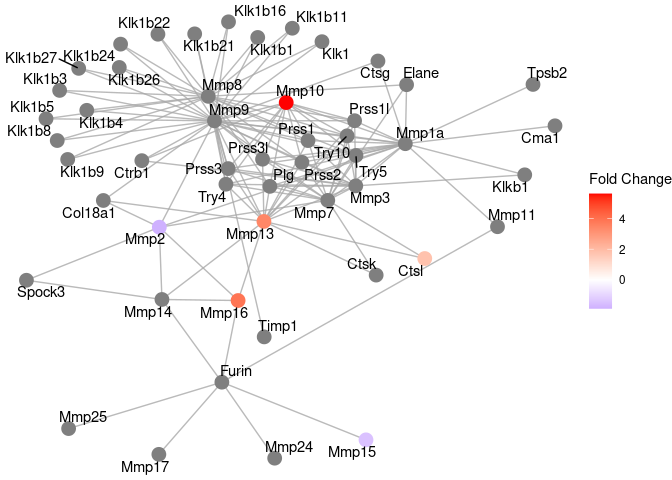

```r
viewPathway("Activation of Matrix Metalloproteinases",
            readable = T,
            foldChange = v_nam,
            organism = "mouse") +
  scale_color_gradient2(low = "blue", mid = "white", high = "red", midpoint = 0) + labs(color = "Fold Change")
```

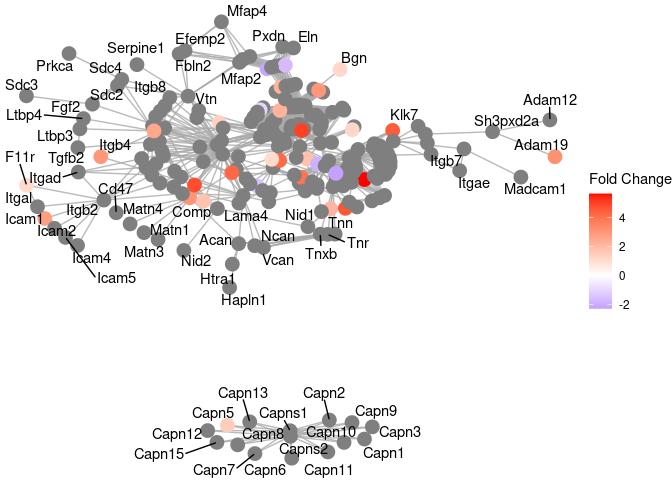

```r
viewPathway("Extracellular matrix organization",
            readable = T,
            foldChange = v_nam,
            organism = "mouse") +
  scale_color_gradient2(low = "blue", mid = "white", high = "red", midpoint = 0) + labs(color = "Fold Change")
```

Here is how the pathway looks in Reactome pathway browser [pathwayBrowser](https://reactome.org/PathwayBrowser/#/R-MMU-109582).

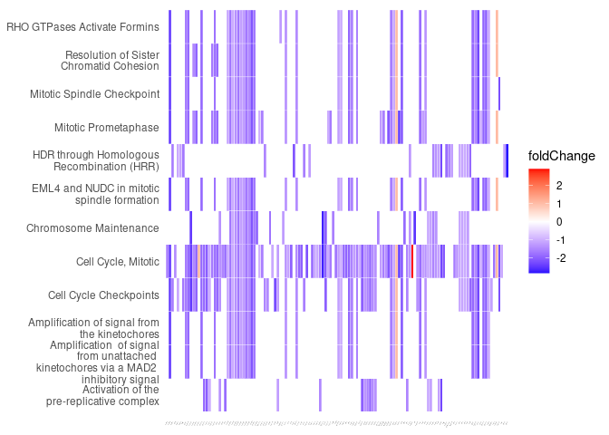

```r
heatplot(r_res, foldChange=v_nam, showCategory=12) + scale_fill_gradient2(low = "blue", mid = "white", high = "red", midpoint = 0) +
  theme(axis.text.x = element_text(size = 1))
```

also plot classical Reactome pathway, and check how it looks with pathview

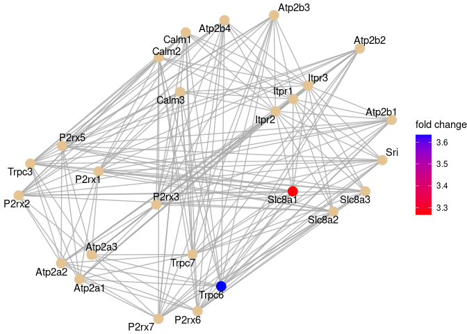

```r
viewPathway("Platelet calcium homeostasis",
            readable = T,
            foldChange = v_nam,
            organism = "mouse")
```

This is how it looks in the Reactome Pathway browser [link](https://reactome.org/PathwayBrowser/#/R-MMU-418346&SEL=R-MMU-418360&PATH=R-MMU-109582)

```r
save.image("RNASeq_LW_all_vs_GM_ORA")
```